# PA1_template

Nitin

July 4, 2019

```r
knitr::opts_chunk$set(echo = TRUE)
```

```r
library(dplyr)
```

```r
library(ggplot2)
```

# 1) Loading and preprocessing the data

### 1. Load the data (i.e. read.csv())

### 2. Process/transform the data (if necessary) into a format suitable for your analysis

```r
data <- read.csv('activity.csv')
data$date <- as.Date(data$date)
str(data)
```

```
## 'data.frame':    17568 obs. of  3 variables:
##  $ steps   : int  NA NA NA NA NA NA NA NA NA NA ...
##  $ date    : Date, format: "2012-10-01" "2012-10-01" ...
##  $ interval: int  0 5 10 15 20 25 30 35 40 45 ...
```

```r
head(str,5)
```

```
##
## 1 function (object, ...)
## 2 UseMethod("str")
```

# 2) What is mean total number of steps taken per day?

For this part of the assignment, you can ignore the missing values in the dataset.

### 1. Calculate the total number of steps taken per day

```r
datewise_mean <- data %>% group_by(date) %>% summarise(mean = mean(steps, na.rm = TRUE) )
```

### 2.Make a histogram of the total number of steps taken each day

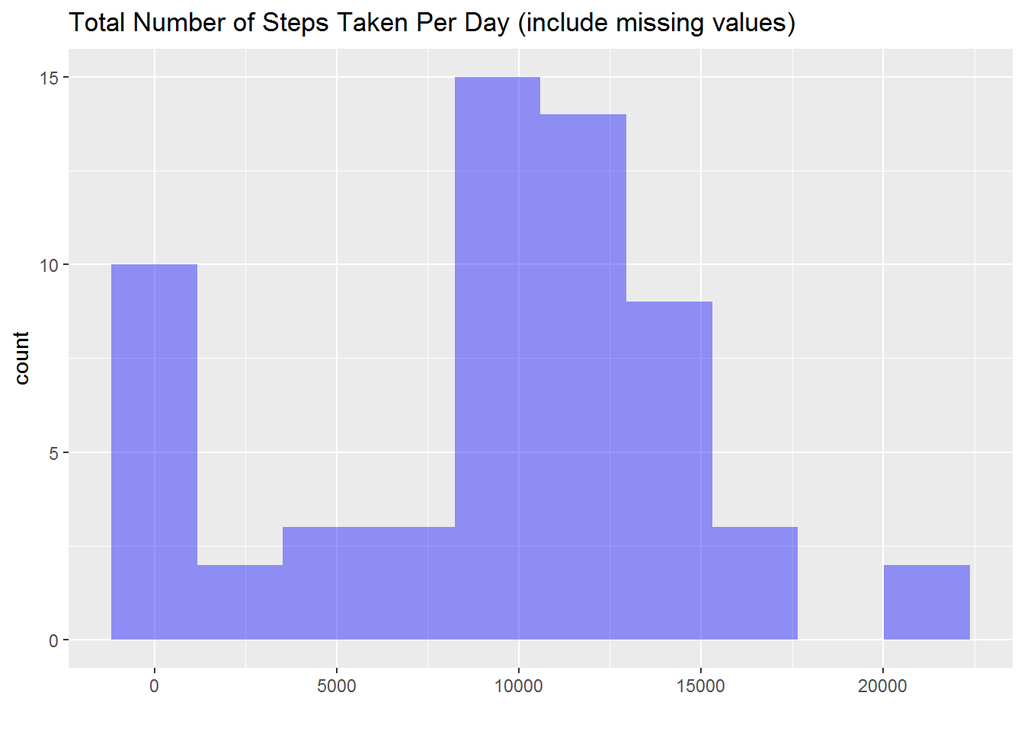

```r
  #agg <- aggregate(steps~date, data, sum)
  agg <- aggregate(data$steps, by = list(data$date), FUN = sum, na.rm=TRUE)
  mean.steps <- round(mean(agg$x, na.rm=TRUE))
  median.steps <- round(median(agg$x, na.rm=TRUE))

  ggplot(agg, aes(x = x)) +
  geom_histogram(bins = 10, fill = rgb(0, 0, 1, .4)) +
  xlab("") +
  ggtitle("Total Number of Steps Taken Per Day (include missing values)")
```

### 3. Calculate and report the mean and median of the total number of steps taken per day

```r
  paste("The Mean number of steps is",mean.steps,"and the Median is",median.steps)
```

```
## [1] "The Mean number of steps is 9354 and the Median is 10395"
```

# 3) What is the average daily activity pattern?

#### 1. Make a time series plot (i.e. type=“l”) of the 5-minute interval (x-axis) and the average number of steps taken, averaged across all days (y-axis)

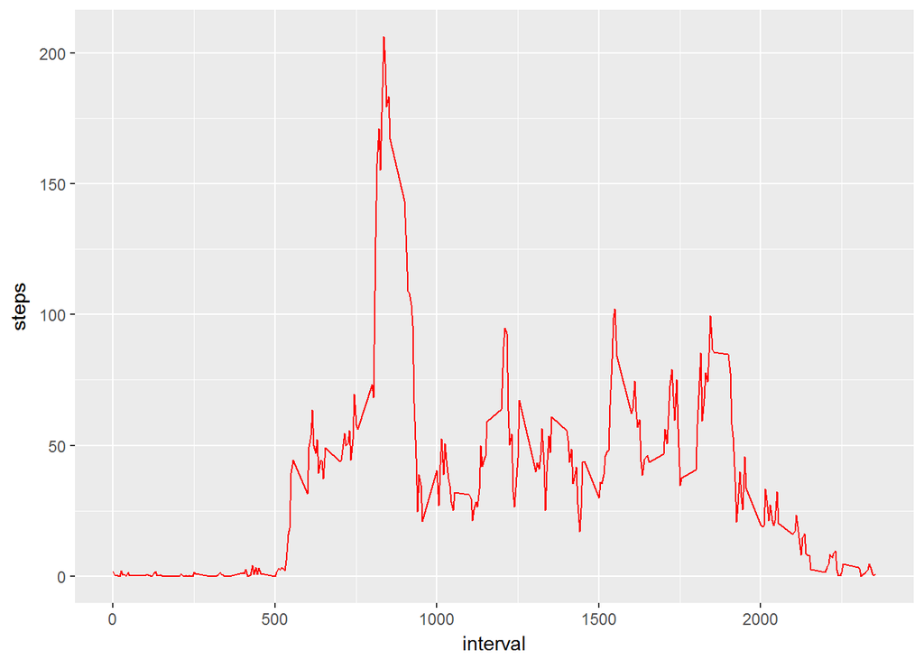

```r
agg_interval <- aggregate(x = list(steps = data$steps), by = list(interval=data$interval), FUN = mean, na.rm=TRUE)

ggplot(agg_interval, aes(x = interval, y = steps)) +
  geom_line(color = "red")
```

```r
max <- max(agg_interval$steps)
```

# 4) Imputing missing values

### 1. Calculate and report the total number of missing values in the dataset (i.e. the total number of rows with NAs)

```r
    paste("The number of missing values in the dataset is", sum(is.na(data$steps)) )
```

```
## [1] "The number of missing values in the dataset is 2304"
```

### 2. Devise a strategy for filling in all of the missing values in the dataset.

Filling all missing values by the mean for that 5-minute interval

Strategy :- Fill with Mean value Create a new dataset that is equal to the original dataset but with the missing data filled in.

```r
interval_avg <- data %>%
  group_by(interval) %>%
  summarise(avg_steps = mean(steps, na.rm = TRUE))
```

### 3. Create a new dataset that is equal to the original dataset but with the missing data filled in.

```r
df_imputed <- data
for (i in 1:nrow(df_imputed)) {
  if (is.na(df_imputed[i, "steps"]) == TRUE) {
    data_interval <- df_imputed[i, "interval"]
    imputed_value <- interval_avg[interval_avg$interval == data_interval, "avg_steps"]
    df_imputed[i, "steps"] <- imputed_value
  } else {
    df_imputed[i, "steps"] <- df_imputed[i, "steps"]
  }
}
```

### 4. Make a histogram of the total number of steps taken each day and Calculate and report the mean and median total number of steps taken per day.

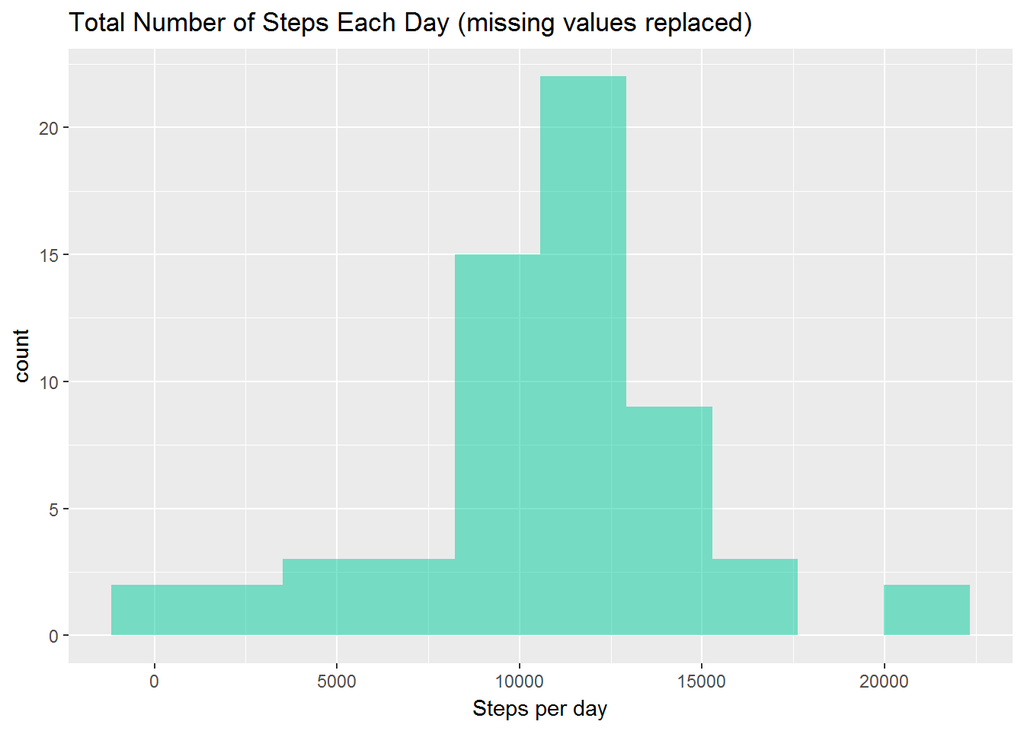

```r
summarized_df <- df_imputed %>%
  group_by(date) %>%
  summarise(ttl_steps = sum(steps, na.rm = TRUE))

ggplot(summarized_df, aes(x = ttl_steps)) +
  geom_histogram(bins = 10, fill = rgb(0, .8, 0.6, 0.5)) +
  xlab("Steps per day") +
  ggtitle("Total Number of Steps Each Day (missing values replaced)")
```

```r
mean_imputed_steps <- mean(summarized_df$ttl_steps)
median_imputed_steps <- median(summarized_df$ttl_steps)

 paste("The Mean number of steps is",mean_imputed_steps,"and the Median is",median_imputed_steps)
```

```
## [1] "The Mean number of steps is 10766.1886792453 and the Median is 10766.1886792453"
```

# 5) Are there differences in activity patterns between weekdays and weekends?

### 1. Create a new factor variable in the dataset with two levels - “weekday” and “weekend” indicating whether a given date is a weekday or weekend day.

```r
data$weekday_indicator <- ifelse(weekdays(data$date) %in% c("Saturday", "Sunday"), "weekend", "weekday")
```

### 2. Make a panel plot containing a time series plot (i.e. type=“l”) of the 5-minute interval (x-axis) and the average number of steps taken, averaged across all weekday days or weekend days (y-axis).

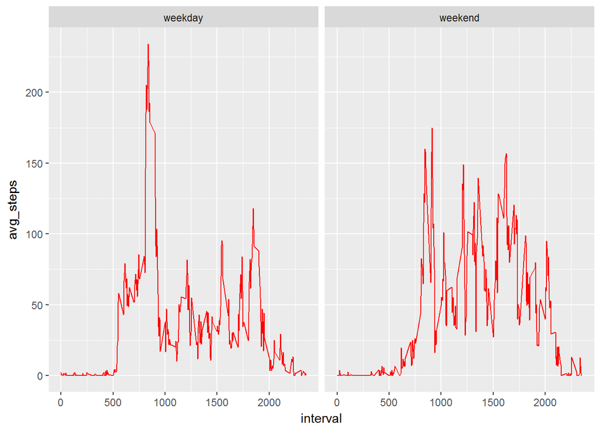

```r
summarized_df <- data %>%
  group_by(interval, weekday_indicator) %>%
  summarise(avg_steps = mean(steps, na.rm = TRUE))

ggplot(summarized_df, aes(x = interval, y = avg_steps)) +
  geom_line(color = "red") +
  facet_wrap(~weekday_indicator)
```